# Summarise from PSM to protein

Tom Smith

Cambridge Centre for Proteomics

07 April, 2022

Abstract

Here, we impute missing values, remove outlier PSMs and aggregate to protein-level

Load libraries

```r
#### Load packages ####
library(camprotR)
library(OptProc)
library(ggplot2)
library(tidyverse)
library(MSnbase)
library(pRoloc)
```

Read in the psm level data

```r
psm_res <- readRDS('../../out/psm_res.rds')
```

For imputation, we will use the ‘sn-knn’ method in `OptProc::imputeOptProc`. This involves:

1. Row sum normalising the `exprs` matrix
2. Performing knn imputation (with k=10 here)
3. ‘De-normalising’ the `exprs` matrix.

```r
psm_res_imputed <- psm_res %>%
  lapply(function(x){
    x %>%
      filterNA(pNA=2/10) %>%
      imputeOptProc(method='sn-knn', k=10, verbose=FALSE)
})
```

Below, we detect PSM outliers by calculating the euclidean distance between all pairs of PSMs for a given protein. Each PSM is then summarised to the median distance to all other PSMs. Where this is above a chosen threshold, the PSM is discarded as an outlier.

First, we obtain the median distances for each PSM to the other PSMs for the same master protein

```r
source('../../../R/psm_outlier_detection.R')

psm_distances <- psm_res_imputed %>%
  lapply(detect_tmt_psm_outliers)
```

```
Identifying outlier PSMs
68538 features found from 7275 master proteins => Input
68538 features found from 7275 master proteins => Filtering PSMs with NAs
67244 features found from 5981 master proteins => Filtering Proteins with <2 PSMs
```

```
Identifying outlier PSMs
78953 features found from 7592 master proteins => Input
78953 features found from 7592 master proteins => Filtering PSMs with NAs
77708 features found from 6347 master proteins => Filtering Proteins with <2 PSMs
```

```
Identifying outlier PSMs
76471 features found from 7369 master proteins => Input
76471 features found from 7369 master proteins => Filtering PSMs with NAs
75267 features found from 6165 master proteins => Filtering Proteins with <2 PSMs
```

[output not shown]

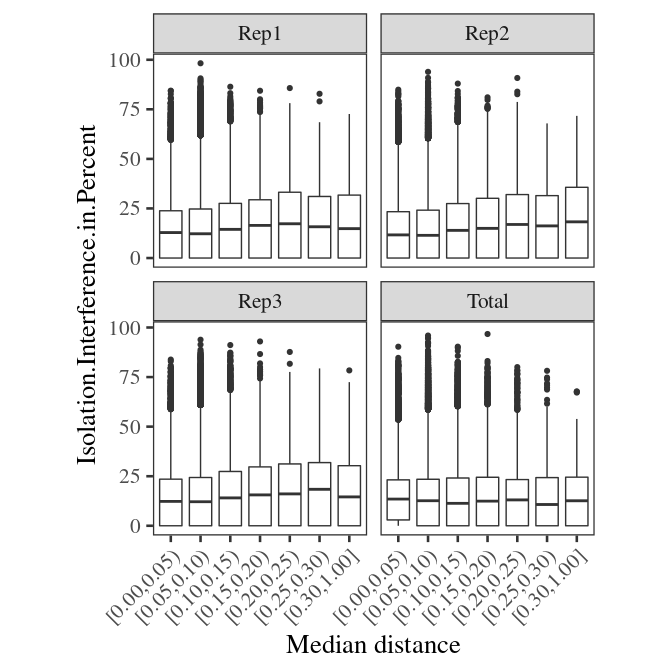

```r
all_psm_distances <- psm_distances %>%
  do.call(what='rbind') %>%
  tibble::rownames_to_column('rep') %>%
  separate(rep, into=c('rep', NA)) %>%
  mutate(binned_median_distance=Hmisc::cut2(median_distance, cuts=c(seq(0,0.3,0.05), 1)))

p <- all_psm_distances %>%
  ggplot(aes(binned_median_distance, Isolation.Interference.in.Percent)) +
  geom_boxplot() +
  theme_camprot() +
  theme(axis.text.x=element_text(angle=45, vjust=1, hjust=1)) +
  xlab('Median distance') +
  facet_wrap(~rep)

print(p)
```

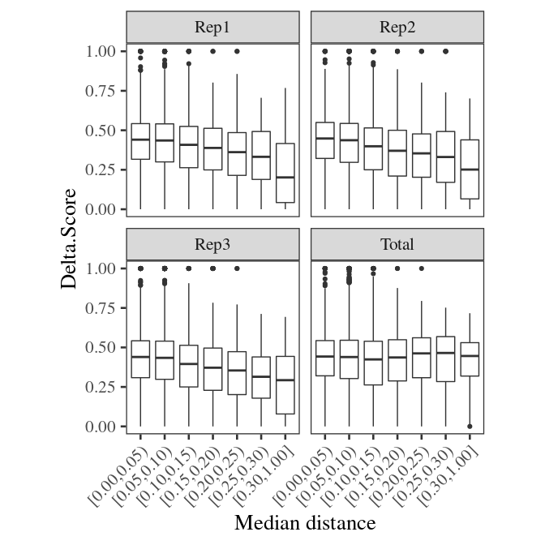

```r
print(p + aes(y=Delta.Score))
```

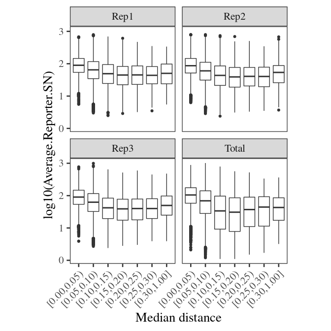

```r
print(p + aes(y=log10(Average.Reporter.SN)))
```

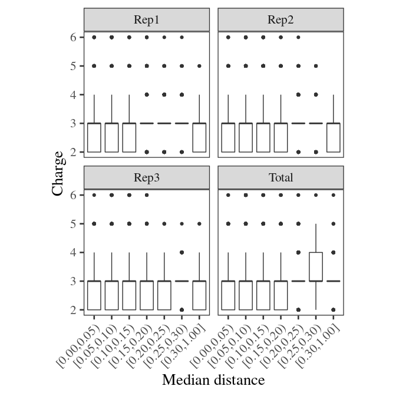

```r
print(p + aes(y=Charge))
```

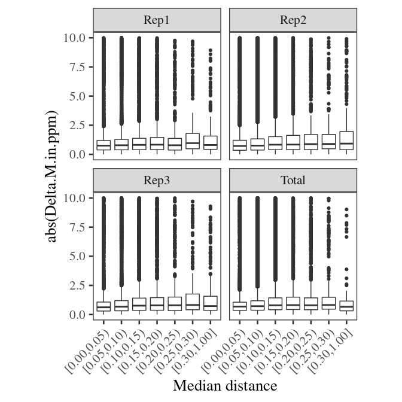

```r
print(p + aes(y=abs(Delta.M.in.ppm)))
```

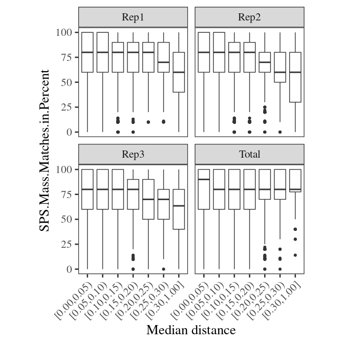

```r
print(p + aes(y=SPS.Mass.Matches.in.Percent))
```

OK, so as expected, PSMs with median distances have: - Higher co-isolation - Lower Delta score - Lower average SN

They also have: - No difference in charge - Slightly larger Delta Mass - Slightly fewer SPS matches

We will use a threshold of 0.2 here.

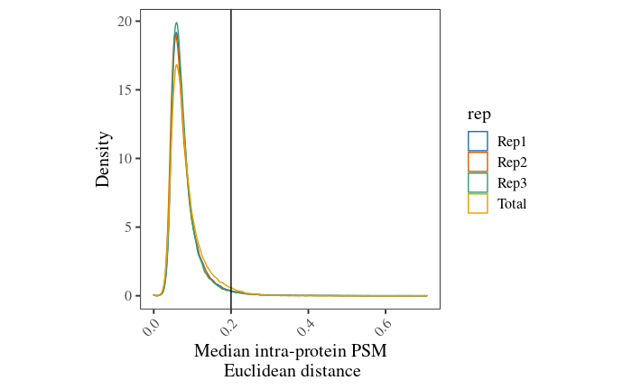

```r
p <- all_psm_distances %>%
  ggplot(aes(median_distance, colour=rep)) +
  geom_density() +
  theme_camprot(base_size=15) +
  theme(axis.text.x=element_text(angle=45, vjust=1, hjust=1)) +
  geom_vline(xintercept=0.2)+
  scale_colour_manual(values=get_cat_palette(4)) +
  xlab('Median intra-protein PSM\n Euclidean distance') +
  ylab('Density')

print(p)
```

```r
all_psm_distances %>% group_by(rep, binned_median_distance) %>% tally() %>% pivot_wider(names_from=rep, values_from=n)
```

| binned_median_distance | Rep1 | Rep2 | Rep3 | Total |
| --- | --- | --- | --- | --- |
| [0.00,0.05) | 10244 | 14146 | 10984 | 14237 |
| [0.05,0.10) | 44212 | 49335 | 51020 | 57830 |
| [0.10,0.15) | 9162 | 10372 | 9577 | 15061 |
| [0.15,0.20) | 2312 | 2493 | 2296 | 4754 |
| [0.20,0.25) | 776 | 799 | 753 | 1535 |
| [0.25,0.30) | 297 | 281 | 297 | 337 |
| [0.30,1.00] | 241 | 282 | 340 | 112 |

```r
all_psm_distances %>% group_by(rep, median_distance<0.2) %>% tally() %>% pivot_wider(names_from=rep, values_from=n)
```

| median_distance < 0.2 | Rep1 | Rep2 | Rep3 | Total |
| --- | --- | --- | --- | --- |
| FALSE | 1314 | 1362 | 1390 | 1984 |
| TRUE | 65930 | 76346 | 73877 | 91882 |

```r
psm_res_filt <- psm_res_imputed %>% names() %>% lapply(function(x){
  psm_to_retain <- psm_distances[[x]] %>% filter(median_distance<0.2) %>% pull(PSM1)
  removed_outliers <- psm_res_imputed[[x]][psm_to_retain, ]
  camprotR:::message_parse(fData(removed_outliers), 'Master.Protein.Accessions', 'Removed PSM outliers')
  return(removed_outliers)
})
```

```
65930 features found from 5945 master proteins => Removed PSM outliers
76346 features found from 6315 master proteins => Removed PSM outliers
73877 features found from 6123 master proteins => Removed PSM outliers
91882 features found from 6685 master proteins => Removed PSM outliers
```

```r
names(psm_res_filt) <- names(psm_res_imputed)
```

Alternative filtering by hard thresholds, sn and delta score and removing One-hit wonders to compare outlier-based approach and hard threshold filtering

```r
#
psm_res_filt_hard <- psm_res %>% lapply(function(x){
  x <- x %>% update_average_sn() %>%
    filter_TMT_PSMs(inter_thresh=50, sn_thresh=10)
  one_hit_wonders <- names(table(fData(x)$Master.Protein.Accessions)[table(fData(x)$Master.Protein.Accessions)==1])
  x <- x[!fData(x)$Master.Protein.Accessions %in% one_hit_wonders,]
  camprotR:::message_parse(fData(x), 'Master.Protein.Accessions', 'Filtering out "one hit wonders"')

  x <- x[fData(x)$Delta.Score>=0.05,]
  camprotR:::message_parse(fData(x), 'Master.Protein.Accessions', 'Filtering out Delta score < 0.05')
  x
})
```

```
Filtering PSMs...
72041 features found from 7362 master proteins => No quant filtering
67018 features found from 7235 master proteins => Co-isolation filtering
63834 features found from 7125 master proteins => S:N ratio filtering
62534 features found from 5825 master proteins => Filtering out "one hit wonders"
59245 features found from 5808 master proteins => Filtering out Delta score < 0.05
Filtering PSMs...
82966 features found from 7675 master proteins => No quant filtering
77311 features found from 7545 master proteins => Co-isolation filtering
72638 features found from 7402 master proteins => S:N ratio filtering
71416 features found from 6180 master proteins => Filtering out "one hit wonders"
67235 features found from 6157 master proteins => Filtering out Delta score < 0.05
Filtering PSMs...
80682 features found from 7473 master proteins => No quant filtering
75195 features found from 7343 master proteins => Co-isolation filtering
69897 features found from 7177 master proteins => S:N ratio filtering
68669 features found from 5949 master proteins => Filtering out "one hit wonders"
64977 features found from 5930 master proteins => Filtering out Delta score < 0.05
Filtering PSMs...
96563 features found from 7878 master proteins => No quant filtering
91447 features found from 7803 master proteins => Co-isolation filtering
84786 features found from 7612 master proteins => S:N ratio filtering
83629 features found from 6455 master proteins => Filtering out "one hit wonders"
79605 features found from 6432 master proteins => Filtering out Delta score < 0.05
```

Compare PSM features in the filtered datasets

```
[1] "No filtering"
[1] "Rep1"
[1] 72041    16
[1] "Rep2"
[1] 82966    16
[1] "Rep3"
[1] 80682    16
[1] "Total"
[1] 96563     6
[1] "Hard filtering"
[1] "Rep1"
[1] 59245    16
[1] "Rep2"
[1] 67235    16
[1] "Rep3"
[1] 64977    16
[1] "Total"
[1] 79605     6
[1] "Outlier filtering"
[1] "Rep1"
[1] 65930    16
[1] "Rep2"
[1] 76346    16
[1] "Rep3"
[1] 73877    16
[1] "Total"
[1] 91882     6
```

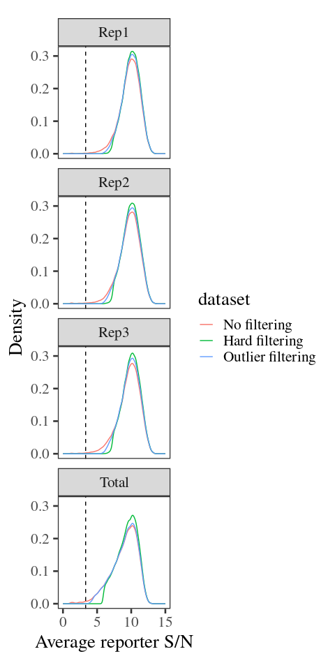

```r
filtering_datasets <- list('No filtering'=psm_res, 'Hard filtering'=psm_res_filt_hard, 'Outlier filtering'=psm_res_filt)

filtering_datasets %>% names() %>% lapply(function(dataset){
  print(dataset)
  filtering_datasets[[dataset]] %>%
    names() %>%
    lapply(function(x){
      print(x)
      print(dim(filtering_datasets[[dataset]][[x]]))
    rowSums(exprs(filtering_datasets[[dataset]][[x]]), na.rm=TRUE) %>%
        data.frame() %>%
        setNames('mean_SN') %>%
        mutate(experiment=x, dataset=dataset)
  }) %>% bind_rows()
})  %>% bind_rows() %>%
  mutate(dataset=factor(dataset, levels=names(filtering_datasets))) %>%
  ggplot(aes(log2(mean_SN), colour=dataset)) +
  geom_line(stat='density') +
  theme_camprot() +
  xlim(0, 15) +
  geom_vline(xintercept=log2(10), linetype=2) +
  facet_wrap(~experiment, ncol=1) +
  xlab('Average reporter S/N') +
  ylab('Density')
```

```
[1] 72041    16
[1] 82966    16
[1] 80682    16
[1] 96563     6
[1] 59245    16
[1] 67235    16
[1] 64977    16
[1] 79605     6
[1] 65930    16
[1] 76346    16
[1] 73877    16
[1] 91882     6
```

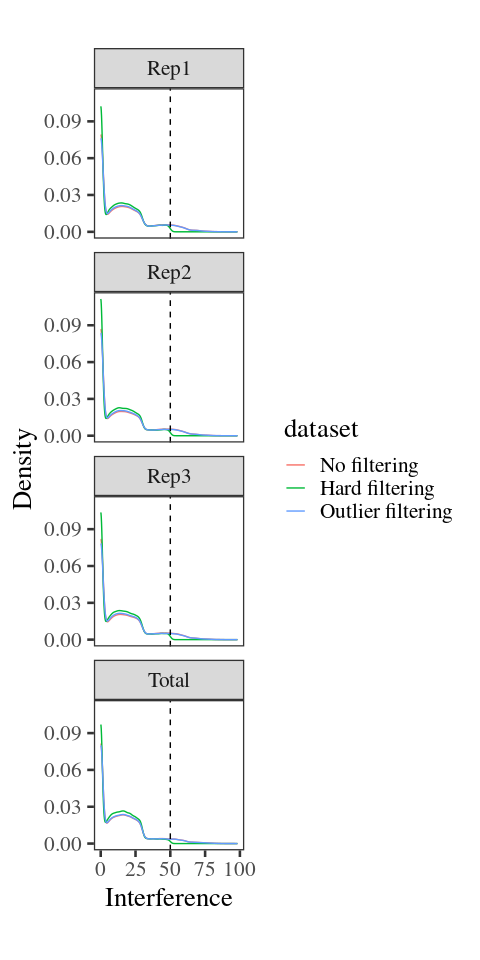

```r
filtering_datasets %>% names() %>% lapply(function(dataset){
  filtering_datasets[[dataset]] %>%
    names() %>%
    lapply(function(x){
      print(dim(filtering_datasets[[dataset]][[x]]))
      fData(filtering_datasets[[dataset]][[x]])[,'Isolation.Interference.in.Percent',drop=FALSE] %>%
        mutate(experiment=x, dataset=dataset)
  }) %>% bind_rows()
})  %>% bind_rows() %>%
  mutate(dataset=factor(dataset, levels=names(filtering_datasets))) %>%
  ggplot(aes(Isolation.Interference.in.Percent, colour=dataset)) +
  geom_line(stat='density') +
  theme_camprot() +
  geom_vline(xintercept=50, linetype=2) +
  facet_wrap(~experiment, ncol=1) +
  xlab('Interference') +
  ylab('Density')
```

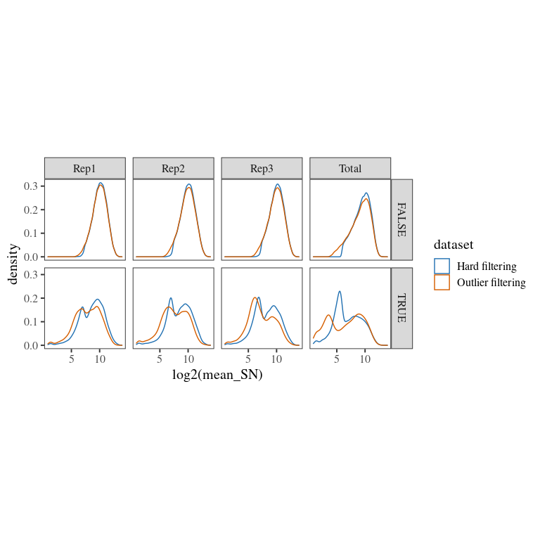

```r
sample='Rep1'
dataset <- 'Outlier filtering'

p <- names(psm_res) %>% lapply(function(sample){
  annotated_psms <- psm_res[[sample]]
  names(filtering_datasets) %>% lapply(function(dataset){
    if(dataset=='No filtering'){
      return(NULL)
    }
    flt_obj <- filtering_datasets[[dataset]]

    fData(annotated_psms)$filtered <- !rownames(annotated_psms) %in% rownames(flt_obj[[sample]])

    mean_sn <- annotated_psms %>%
      exprs() %>%
      rowSums(na.rm=TRUE)

    fData(annotated_psms) %>%
      data.frame() %>%
      mutate(mean_SN=mean_sn) %>%
      mutate(sample=sample, dataset=dataset)

  }) %>% bind_rows()
}) %>% bind_rows() %>%
  ggplot(aes(log2(mean_SN), colour=dataset)) +
  geom_density() +
  theme_camprot(base_size=15) +
  facet_grid(filtered~sample) +
  scale_colour_manual(values=get_cat_palette(2))

print(p)
```

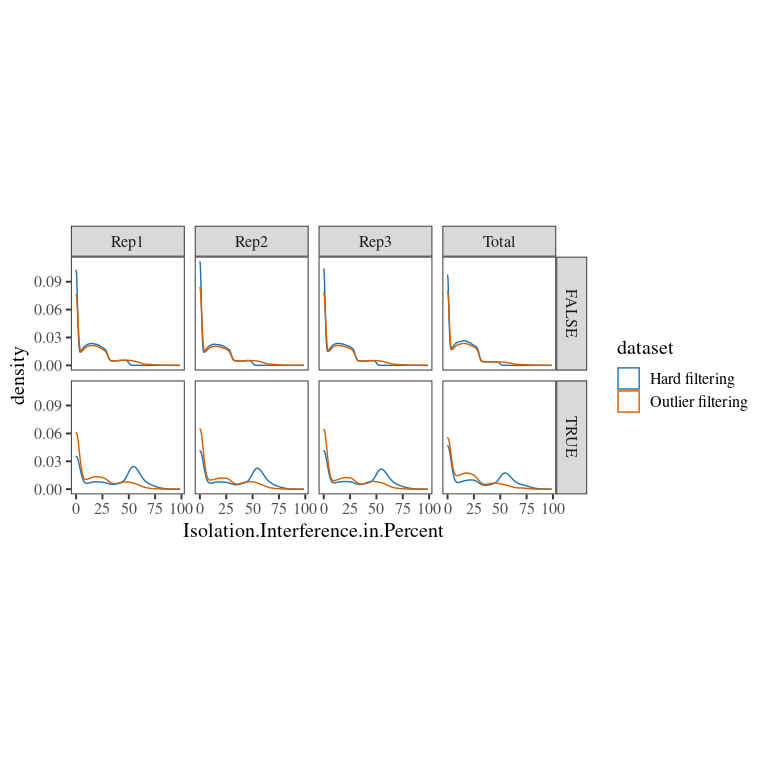

```r
print(p + aes(Isolation.Interference.in.Percent))
```

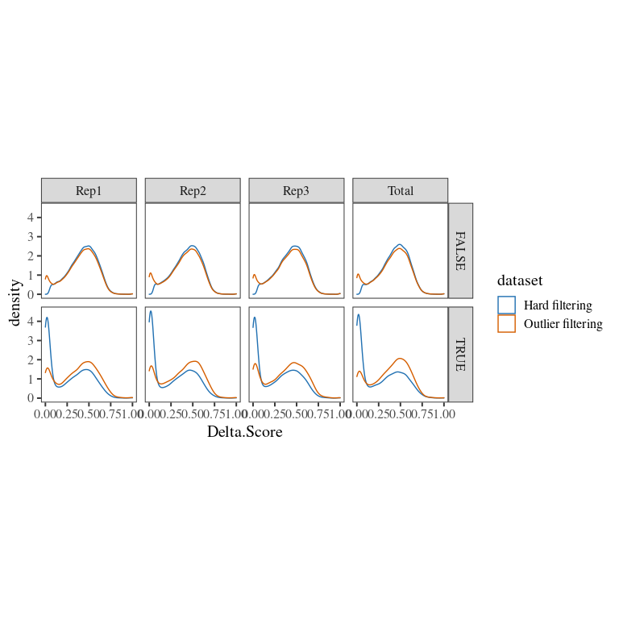

```r
print(p + aes(Delta.Score))
```

Summarise to protein-level abundance using simple sum of PSM intensities.

```r
protein_res <- psm_res_filt %>% lapply(function(x){
  psm_res_filt_log <- x %>%
    log(base=2)

  psm_res_filt_no_na <- psm_res_filt_log %>%
    center_normalise_to_ref(medians=get_medians(psm_res_filt_log)) %>%
    filterNA(pNA=0)

  exprs(psm_res_filt_no_na) <- 2^exprs(psm_res_filt_no_na)
  print(dim(psm_res_filt_no_na))

  retain_proteins <- psm_res_filt_no_na %>% fData() %>%
    group_by(Master.Protein.Accessions) %>%
    tally() %>%
    filter(n>=2) %>%
    pull(Master.Protein.Accessions)

  psm_res_filt_no_na_min_2_psm <- psm_res_filt_no_na[
    fData(psm_res_filt_no_na)$Master.Protein.Accessions %in% retain_proteins]

  print(dim(psm_res_filt_no_na_min_2_psm))

  group_protein <- fData(psm_res_filt_no_na_min_2_psm)$Master.Protein.Accessions

  psm_res_filt_no_na_min_2_psm %>%
    MSnbase::combineFeatures(group=group_protein, method='sum')
})
```

```
[1] 65930    16
[1] 65924    16
[1] 76346    16
[1] 76342    16
[1] 73877    16
[1] 73873    16
[1] 91882     6
[1] 91877     6
```

```r
protein_res %>% lapply(dim)
```

```
$Rep1
[1] 5939   16

$Rep2
[1] 6311   16

$Rep3
[1] 6119   16

$Total
[1] 6680    6
```

Add markers. Here, we use the same markers as Aikaterini Geladaki et al (2019) - https://www.nature.com/articles/s41467-018-08191-w

```r
markers_df <- read.delim("../../../shared_files/markers_9B_hyperLOPIT_vs_DC.csv", sep=",", header=FALSE, stringsAsFactors=FALSE)[,1:2]
markers_df$V2 <- recode(markers_df$V2,
                        #"NUCLEUS-CHROMATIN"="NUCLEUS",
                        "RIBOSOME 40S"="RIBOSOME",
                        "RIBOSOME 60S"="RIBOSOME")

markers_proteins <- markers_df$V2
names(markers_proteins) <- markers_df$V1

protein_res <- protein_res %>% lapply(function(x) addMarkers(x, markers_proteins))
```

```
Markers in data: 689 out of 5939
```

```
organelleMarkers
          CYTOSOL                ER             GOLGI          LYSOSOME      MITOCHONDRIA           NUCLEUS
               77                90                42                29               157                80
NUCLEUS-CHROMATIN        PEROXISOME                PM        PROTEASOME          RIBOSOME           unknown
               40                15                61                31                67              5250
```

```
Markers in data: 712 out of 6311
```

```
organelleMarkers
          CYTOSOL                ER             GOLGI          LYSOSOME      MITOCHONDRIA           NUCLEUS
               77                91                46                32               160                82
NUCLEUS-CHROMATIN        PEROXISOME                PM        PROTEASOME          RIBOSOME           unknown
               42                18                67                31                66              5599
```

```
Markers in data: 699 out of 6119
```

```
organelleMarkers
          CYTOSOL                ER             GOLGI          LYSOSOME      MITOCHONDRIA           NUCLEUS
               78                90                41                32               158                81
NUCLEUS-CHROMATIN        PEROXISOME                PM        PROTEASOME          RIBOSOME           unknown
               43                14                65                31                66              5420
```

```
Markers in data: 709 out of 6680
```

```
organelleMarkers
          CYTOSOL                ER             GOLGI          LYSOSOME      MITOCHONDRIA           NUCLEUS
               82                87                44                30               162                83
NUCLEUS-CHROMATIN        PEROXISOME                PM        PROTEASOME          RIBOSOME           unknown
               44                15                65                31                66              5971
```

Plot tag intensities at PSM and protein level

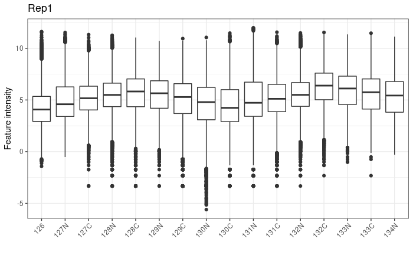

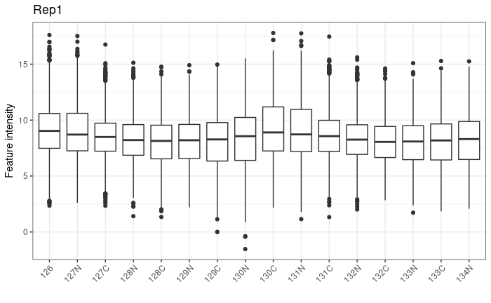

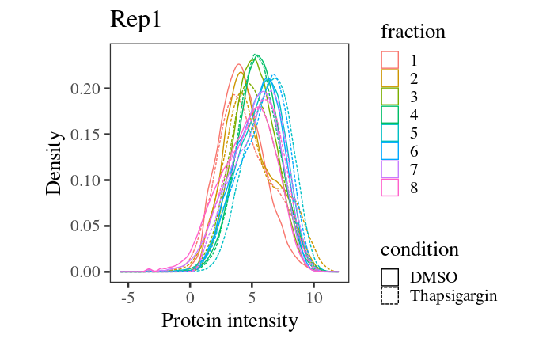

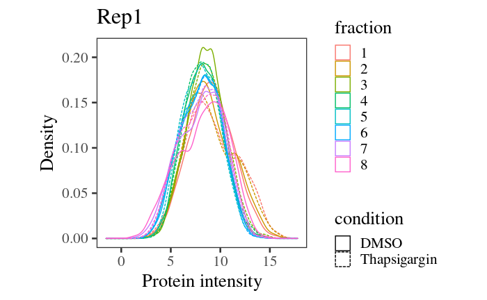

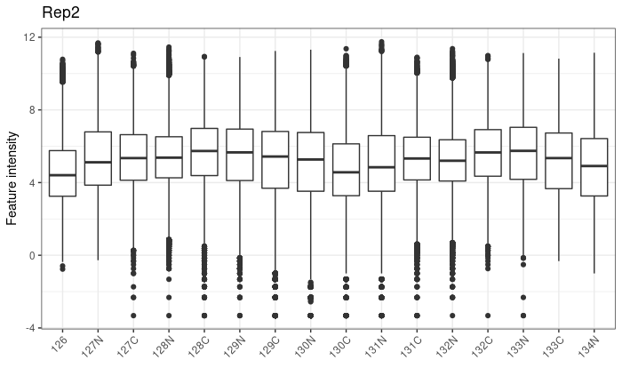

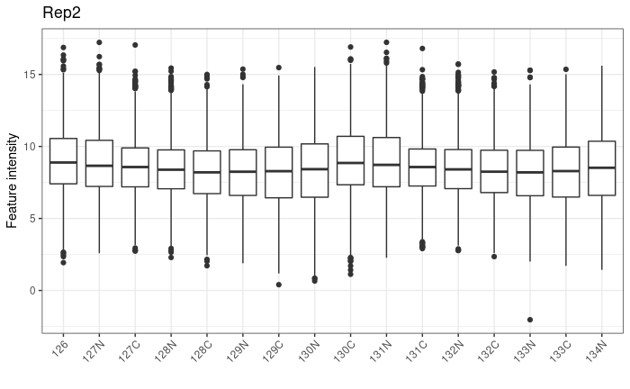

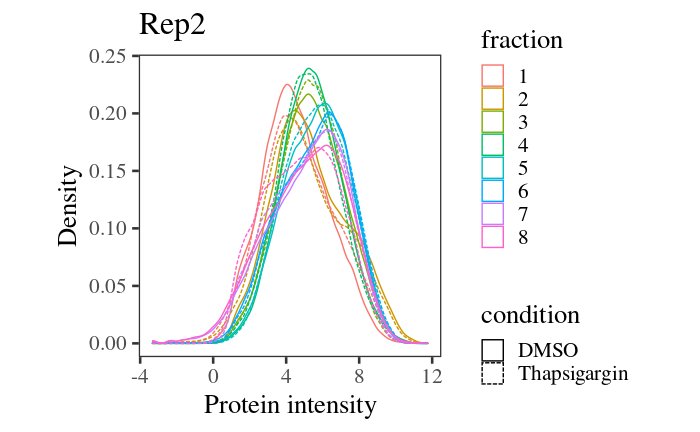

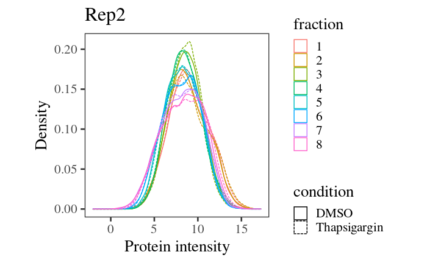

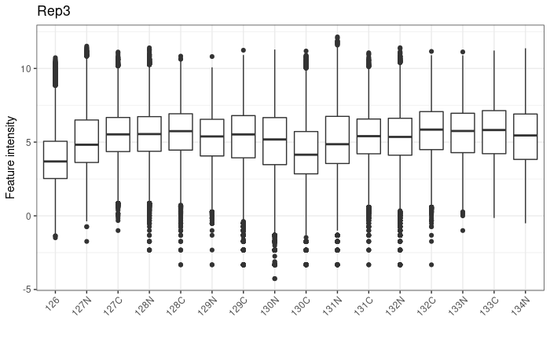

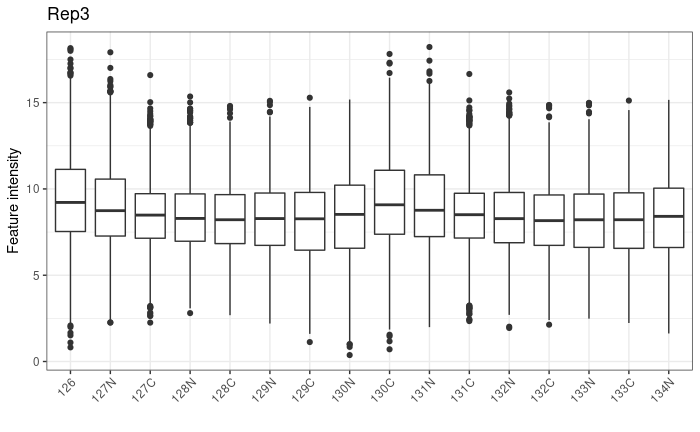

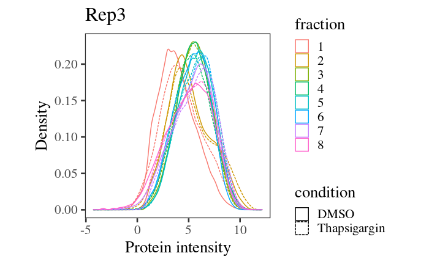

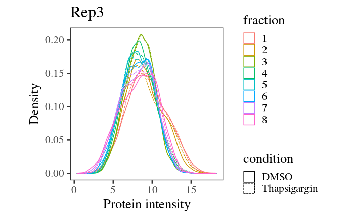

[2 more figures not shown]

```r
source('../../../R/tag_intensity_density.R')

psm_res_filt %>% names() %>% lapply(function(x){

  p <- psm_res_filt[[x]] %>% log(base=2) %>% plot_quant() + ggtitle(x)
  print(p)


  p <- protein_res[[x]] %>% log(base=2) %>% plot_quant() + ggtitle(x)
  print(p)

  if(x != 'Total'){
    p <- psm_res_filt[[x]] %>% log(base=2) %>% plot_quant_density_tg()  +
      xlab("Protein intensity") + ggtitle(x)
    print(p)


    p <- protein_res[[x]] %>% log(base=2) %>% plot_quant_density_tg()  +
      xlab("Protein intensity") + ggtitle(x)
    print(p)
  }

  return(NULL)
})
```

Make combined datasets for replicates of Ctrl and Tg

When combining features across the replicates, it makes sense to first normalise the abundances within each experiment. Otherwise, a protein quantified with more PSMs in one replicate will appear to be more abundant in this replicate.

```r
# We will need to update most feature names (using MSnbase::updateFvarLabels).
# However, for some feature, we don't want to update. For example, we only want a
# single 'Sequence' column. This function reverts the feature name update for
# the desired columns
revert_update <- function(colnames,
                          suffix,
                          remove_prefixes){
  remove_match = paste0(remove_prefixes, suffix)
  matches <- which(colnames %in% remove_match)
  removed_colnames <- gsub(suffix, '', colnames)
  colnames[matches] <- removed_colnames[matches]
  colnames
}

# To combine the 3 replicates, we need to update feature and sample names,
# and then use MSnbase:combine twice.
combine_three_reps <- function(obj,
                               condition_grep,
                               remove_prefixes=c('Master.Protein.Accessions','markers')){

  reps <- obj %>% names() %>% lapply(function(x){

    updated <- obj[[x]][,grepl(condition_grep, pData(obj[[x]])$condition)] %>%
      updateFvarLabels(label=x) %>%
      updateSampleNames(label=x)

    fvarLabels(updated) <- revert_update(fvarLabels(updated),
                                         remove_prefixes,
                                         suffix=sprintf('.%s', x))

    updated
  })

  all_reps <- MSnbase::combine(
    normalise(reps[[1]], 'sum'),
    MSnbase::combine(normalise(reps[[2]], 'sum'),
                     normalise(reps[[3]], 'sum')))

  pData(all_reps)$replicate <- rep(1:3, each=8)
  all_reps
}


combined_ctrl <- combine_three_reps(protein_res[paste0('Rep', 1:3)], condition_grep='DMSO')
combined_tg <- combine_three_reps(protein_res[paste0('Rep', 1:3)],condition_grep='Thapsigargin')
```

```r
combined_protein_res <- c(combined_ctrl, combined_tg)
names(combined_protein_res) <- c('DMSO', 'Thapsigargin')
combined_protein_res %>% lapply(dim)
```

```
$DMSO
[1] 6927   24

$Thapsigargin
[1] 6927   24
```

```r
table(rowSums(is.na(exprs(combined_protein_res$DMSO))))
```

```
   0    8   16
5314  814  799
```

```r
table(rowSums(is.na(exprs(combined_protein_res$Thapsigargin))))
```

```
   0    8   16
5314  814  799
```

Save the results for downstream notebooks

```r
saveRDS(protein_res, '../../out/protein_res.rds')
saveRDS(combined_protein_res, '../../out/combined_protein_res.rds')
saveRDS(psm_res_filt, '../../out/psm_res_filt.rds')
saveRDS(psm_distances, '../../out/psm_distances.rds')
```